# RiboDiPA R package

Keren Li, Matthew Hope, Xiaozhong A. Wang, Ji-Ping Wang

02/20/2020

#### Maintainer: Ji-Ping Wang, <jzwang@northwestern.edu>

**Reference**: Li, K., Hope, M., Wang, X., Wang, J.-P., RiboDiPA: A novel tool for differential pattern analysis in Ribo-seq data, 2020

## What is RiboDiPA?

Ribosome profiling (also known as Ribo-seq) is an cutting-edge technique to investigate translational activities across a wide variety of contexts. Ribo-seq data not only provides the abundance of ribosomes bound to transcripts for quantification of translational efficiency, but also positional information across transcripts that could be indicative of differences in translation dynamics between conditions. We are particularly interested in statistical inference of translational differences between conditions using Ribo-seq data. In this regard, most existing tools focuse on differentiation of translational efficiency between conditions based on the gene-wise Ribo-seq counts. The translational efficiency for each gene is typically quantified by Ribo-seq read count normalized by the RNA-seq gene expression. While these approaches can provide insight into translational efficiency, the ribosome binding pattern along the gene body, which we believe can provide a more complete picture of transcriptional and translational variations across conditions, has been mostly ignored.

**RiboDiPA**, short for **Ribo**some **Di**ferential **P**attern **A**nalysis, is a bioinformatics pipeline developed for differential pattern analysis of Ribo-seq footprint data that allows quick identification of genes with statistically significant differences in ribosome footprint occupancy patterns between conditions.

## RiboDiPA pipline available format

RiboDiPA is an R package that utilizes parallel computing functionality with some core functions written in C++.

## RiboDiPA input

1. Ribo-seq alignment (.bam) files, one per sample.
2. Genome Transfer File (GTF) for the reference genome.

## RiboDiPA main features

1. **GTF file parsing and exon merging**: A total transcript is compile for each gene by concatenating all exons from the same gene.
2. **BAM file processeing and P-site mapping**: process the Ribo-seq alignment file (.bam) to calculate the P-site position for each RPF with reference to the total transcript of each gene. The Ribo-seq footprint, represented by the mapped P-site frequency at each nucleotide position along the total transcript is compiled for each gene of each sample.
3. **Data binning**: merge P-site postion data into bins with a user-customizable fixed bin width (as small as per codon) or an adapte width using a built-in binning method.
4. **Differential pattern analysis**: perform the differential pattern analysis on the data, output statistical significance including $p$-value and $q$-value together with a supplementary statistics $T$-value. The $T$-value can be used to identify genes that contain larger regions of differential codons/bins among the significant genes.
5. **Visualization of Ribo-seq footprint**: RiboDiPA also provides a function for visualization the Ribo-seq footprint of genes.

The following diagram illustrates the flow of RiboDiPA pipeline.

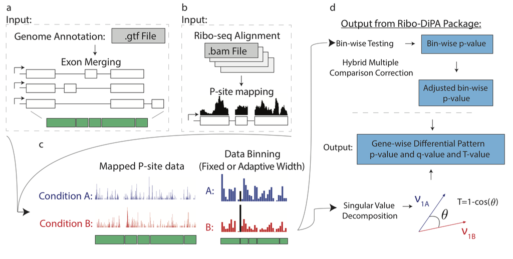

A diagram of RiboDiPA.

## RiboDiPA functions

The following vignette is intended to provide example codes for running RiboDiPA R package. It presumes that you have successfully installed RiboDiPA package. We illustrate below how to: 1) process bam file and map the P-site positions with reference to total transcript for all genes within all samples; 2) bin the mapped P-site frequency footprint; and 3) perform the differential pattern analysis.

All three steps are computing intensive. The computing time depends upon the number of samples, the sequencing depth and the complexity of the organism. For example the total computing time of the WT vs. erf1d comparison from yeast data from Wu data set (4 samples) on a 20-core node is about 10 minutes. In the P-site mapping and data binning steps, RiboDiPA utilizes the parallel computing functionality of R and automatically detects the number of cores on your computer to run jobs in parallel. Due to the large size of bam file and limited computing power of personal computer, we recommend users to run it in servers or computing clusters.

### 1. P-site mapping

##### Set up inputs: alignment files (.bam) and GTF files (.gtf).

```r
## specify bam_files from Ribo-seq, you should replace it by your own bam files
bam_file_list <- list.files(path=system.file("extdata",package="RiboDiPA"),
                        pattern=".bam$", full.names=TRUE)
names.sample <- sub("(.*\\/)([^.]+)(\\.[[:alnum:]]+$)", "\\2", bam_file_list)
```

```r
## gtf_file you used for Ribo-seq alignment, replace it by corresponding gtf file
gtf_file <- list.files(path=system.file("extdata",package="RiboDiPA"),
                    pattern=".gtf$", full.names=TRUE)
```

##### P-site mapping

```r
## convert RPF reads into the P-site position on merged exons
psite.mapping <- cbind(qwidth=20:32,psite=c(12,13,13,13,13,13,13,12,12,13,13,13,13))
data.psite <- PsiteMapping(bam_file_list=bam_file_list, gtf_file=gtf_file, psite.mapping=psite.mapping, cores=NULL)
```

The function `PsiteMapping` returns a list of four elements: `coverage`, `counts`, `exons`, and `psite.mapping`. `coverage`is a list of matrices, with each element represents the Ribo-seq (P-site) footprint of a gene. Rows corrspond to replicates and columns corrspond to nucleotide positions with reference to the total transcript. `counts` is a mtrix of read counts where each row stand for a gene and each column for a sample. `exons` is a list of relative start and end positions of exons in each gene to the total transcript. `psite.mapping` is the P/A-site mapping rule.

If `psite.mapping` is not specified, If `psite.mapping` is unspecified, an optimal P-site offsets based on data is calibrated using a two-step algorithm on start codons of CDS following Lauria et al (2018). First, the offset of each read length is defined as the distances between the first nucleotide of start codons and the nucleotide corresponding to the maximum found in the profiles of the start codons. The temporary global offset is defined to be the offset of the read length with maximum count. Next, for each read length, the adjusted offset is defined to be the one corresponding to the local maximum found in the profiles of the start codons closest to the temporary global offset.

If `cores` is not specified, this function will automatically detect the number of cores on your computer to run jobs in parallel.

### 2. Data binning

```r
## merge the P-site data into bins with a fixed or an adaptive width
data.binned <- DataBinning(data=data.psite$coverage, bin.width=1, zero.omit=F, bin.from.5UTR=T, cores=NULL)
```

This function `DataBinning` returns a list of binned P-site footprint matrices. In each matrix, rows corrspond to replicates, columns corrspond to codons/bins. If value of ‘bin.width’ is specified, the footprint data is binned with ‘bin.width’ codons per bin. If ‘bin.width’ is not specified or equal `0`, an adaptive bin width is calcualted using the Freedman-Diaconisis rule. In general we recommend to use adpative binning due to the low read count per codon typically observed for Ribo-seq data. Alterntively uses can specify a smaller value for ‘bin.width’ (a minimum of 1 for codon level analysis) for fine-scale pattern analysis

When the length of total transcript is not an integer multiple of the binning width, binning will start from the 5’ end if `bin.from.5UTR` argument is `TRUE`, or from the 3’ end otherwise. If the `zero.omit` argument is `TRUE`, bins with all zeros across replicates are removed from the differential pattern analysis.

### 3. Differential pattern analysis algorithm

```r
## perform differential pattern analysis
classlabel <- data.frame("condition"=c(rep("A",2),rep("B",2)),
                         "type"=names.sample,"comparison"=c(1,1,2,2))
rownames(classlabel) <- names.sample
result.pst <- RiboDiPA(data=data.binned, classlabel=classlabel,
                   method=c('gtxr','qvalue'))
result.pst$gene
```

```
#>             tvalue       pvalue       qvalue
#> YCR076C 0.08024215 9.993758e-01 9.998607e-01
#> YDL160C 0.06009355 9.242224e-01 9.998607e-01
#> YDR086C 0.34976814 4.102696e-13 4.102696e-12
#> YDR148C 0.08099411 3.333678e-01 9.998607e-01
#> YDR210W 0.31982445 7.658630e-10 3.829315e-09
#> YDR400W 0.07960790 9.991307e-01 9.998607e-01
#> YFR047C 0.08576016 9.943428e-01 9.998607e-01
#> YGL097W 0.08407233 9.987185e-01 9.998607e-01
#> YGR193C 0.08001507 9.998607e-01 9.998607e-01
#> YOL146W 0.06674621 9.976214e-01 9.998607e-01
```

RiboDiPA also ouputs a supplementary measure called $T$-value, which is defined to be 1-cosine of the angle between the first right singular vectors of the footprint matrices of the two conditions under comparison. It can be used to identify genes with larger magnitude of pattern difference beyond statistical significance.

### 4. Plotting

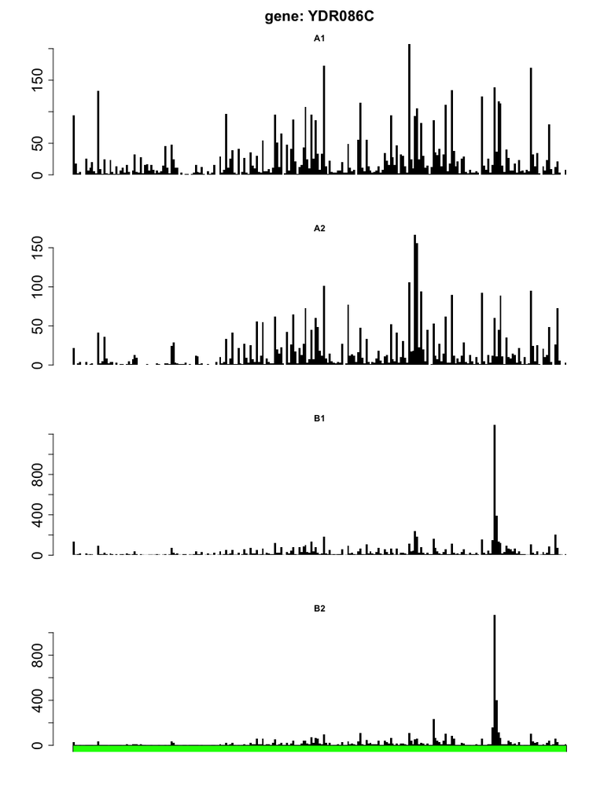

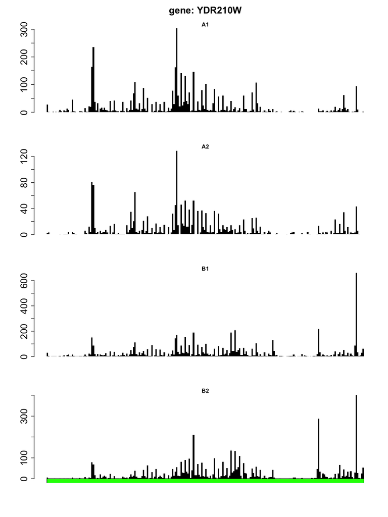

```r
## plot ribosome per nucleotide tracks of specified genes.
plot_track(data=data.psite, genes.list=c("YDR086C","YDR210W"), replicates=NULL,exons=FALSE)
```

This function `plot_track` visualizes the Ribo-seq per nucleotide footprint on merged exons of the genes specified in `genes.list` and replicates specified in `replicates`. If `replicates` is not specified, all replicates of specified genes will be output. If `exons` is `TRUE`, Ribo-seq footprint per exon of specified genes is also output.

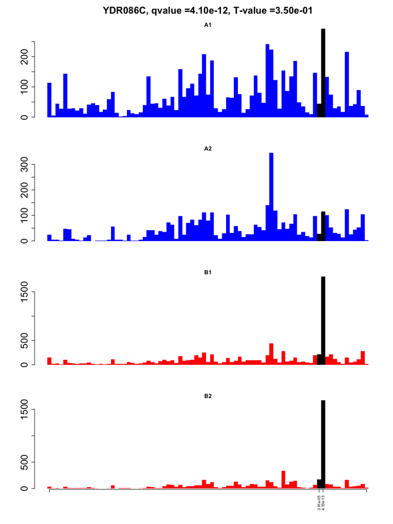

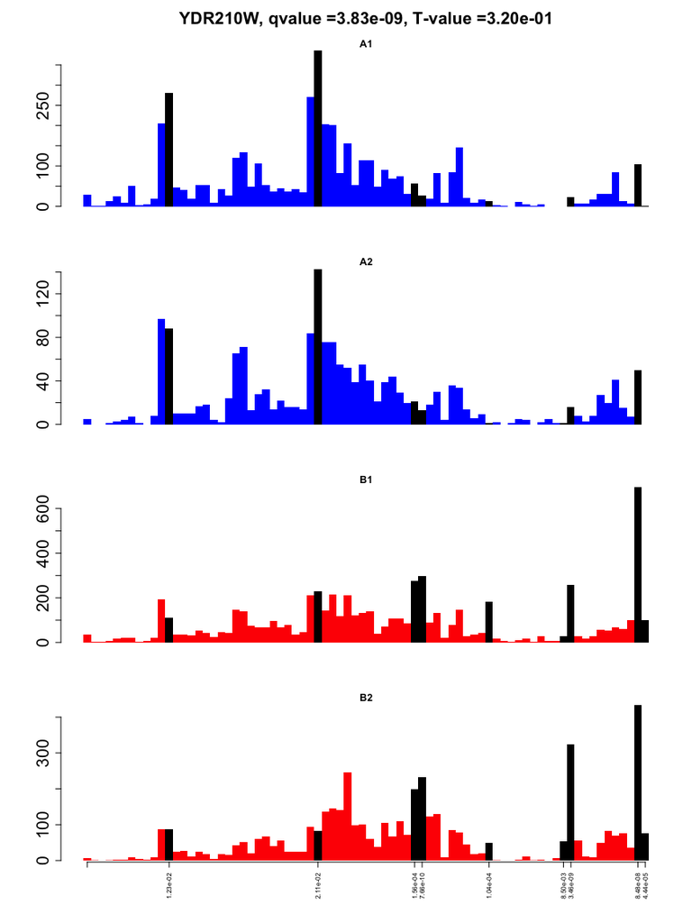

```r
## plot binned ribosome tracks of siginificant genes: YDR086C and YDR210W.
## you can specify the thrshold to redefine the significant level
plot_test(result=result.pst, genes.list=c("YDR086C","YDR210W"), threshold=0.05)
```

This function `plot_test` visualizes the Ribo-seq bin-level footprint of the genes specified in the `genes.list`. For replicates marked as `1` in `classlabel` (see `RiboDiPA` function), the tracks are colored blue and replicates marked as `2` are colored red. Differential bins are colored black, with bin-level adjusted $p$-value annotated underneath the the track of the last replicate. If `genes.list` is not specified, all genes with significant differential pattern will be output.